# Meta-Analytic Structural Equation Modeling

Mike Cheung

8-10 Feb 2023 (Day 1, Session 1)

# Introduction

# Who is the instructor?

- [Prof Mike Cheung](https://mikewlcheung.github.io/) is a Professor at the [Department of Psychology](https://fass.nus.edu.sg/psy/) and a Professor (courtesy appointment) at [the Department of Management & Organisation](https://bschool.nus.edu.sg/management-organisation), NUS.
  - General research area: quantitative methods
  - Specific research topics: Structural equation modeling (SEM), meta-analysis, multilevel model, analysis of missing data, longitudinal data analysis, analysis of non-normal data, etc.
  - Main research question: integrating meta-analysis and SEM into a single framework
  - Book: [*Meta-Analysis: A Structural Equation Modeling Approach*](https://www.wiley.com/en-us/Meta+Analysis%3A+A+Structural+Equation+Modeling+Approach-p-9781119993438)

[figure not shown]

- Author of the [metaSEM](https://github.com/mikewlcheung/metasem), [symSEM](https://github.com/mikewlcheung/symsem), and [mulSEM](https://github.com/mikewlcheung/mulsem) packages in R.
- Editorial positions:
  - Associate editor: [*Research Synthesis Methods*](https://onlinelibrary.wiley.com/journal/17592887) and [*Neuropsychology Review*](https://www.springer.com/journal/11065).
  - Editorial board:
    - Current: [*Health Psychology Review*](https://www.tandfonline.com/toc/rhpr20/current), [*Psychological Bulletin*](https://www.apa.org/pubs/journals/bul), [*Journal of Management*](https://journals.sagepub.com/home/jom), and [*Methods in Psychology*](https://www.journals.elsevier.com/methods-in-psychology/)
    - Past: [*Psychological Methods*](https://www.apa.org/pubs/journals/met) (2011-2019), [*Research Synthesis Methods*](https://onlinelibrary.wiley.com/journal/17592887) (2013-2016), and [*Educational Researcher*](https://journals.sagepub.com/home/edr) (2010-2012).

# Materials

- Workshop notes: Notes, slides, and suggested readings.
- Statistical platform
  - [R](https://www.r-project.org/)
  - [RStudio](https://www.rstudio.com/products/rstudio/download/)
  - Folder for the data (if any)
  - R code for the analyses
- In this workshop, we will use the metaSEM package to conduct the analyses in R. You may need to install the following packages in R before running the analyses.

```r
## Install packages automatically if they are not available on your computer
for (i in c("metaSEM", "symSEM", "lavaan", "semPlot", "readxl")) {
  if (!(i %in% rownames(installed.packages()))) install.packages(i)
}
```

# Objectives of the workshop

- This workshop provides a practical introduction to meta-analytic structural equation modeling (MASEM) using the open-source R statistical platform.
- **Expectations**:
  1. Review essential ideas of SEM and meta-analysis;
  2. Learn basic and advanced techniques in MASEM;
  3. Learn how to conduct and interpret MASEM in R.
  4. But don’t expect to be an expert in MASEM in 3 days!

# Approximate schedule

- Day 1:
  - Session 1: Introduction to structural equation modeling (SEM)
  - Session 2: Introduction to meta-analysis
- Day 2:
  - Session 1: Introduction to MASEM
  - Session 2: Advanced MASEM
- Day 3:
  - Session 1: Hands-on practice in R
  - Session 2: Tips and tricks in doing MASEM

# Suggested readings

- SEM
  - Hox, J. & Bechger, T. (1999) [An Introduction to structural equation modeling](http://joophox.net/publist/semfamre.pdf). *Family Science Review*, *11*, 354-373.
- Meta-analysis
  - Cheung, M. W.-L. (2019). A guide to conducting a meta-analysis with non-independent effect sizes. *Neuropsychology Review*, *29*(4), 387–396. https://doi.org/10.1007/s11065-019-09415-6
  - Cheung, M. W.-L., & Vijayakumar, R. (2016). A guide to conducting a meta-analysis. *Neuropsychology Review*, *26*(2), 121–128. https://doi.org/10.1007/s11065-016-9319-z
  - Mak, A., Cheung, M. W.-L., Fu, E. H. Y., & Ho, R. C. M. (2010). Meta-analysis in medicine: An introduction. *International Journal of Rheumatic Diseases*, *13*(2), 101–104. https://doi.org/10.1111/j.1756-185X.2010.01471.x
- Meta-analytic structural equation modeling (MASEM)
  - Cheung, M. W.-L. (2014). Fixed- and random-effects meta-analytic structural equation modeling: Examples and analyses in R. *Behavior Research Methods*, *46*(1), 29–40. https://doi.org/10.3758/s13428-013-0361-y
  - Cheung, M. W.-L. (2021). Meta-analytic structural equation modeling. In *Oxford Research Encyclopedia of Business and Management*. Oxford University Press. https://doi.org/10.1093/acrefore/9780190224851.013.225
- Examples and applications
  - Cheung, M. W.-L., & Hong, R. Y. (2017). Applications of meta-analytic structural equation modelling in health psychology: Examples, issues, and recommendations. *Health Psychology Review*, *11*(3), 265–279. https://doi.org/10.1080/17437199.2017.1343678
  - Schutte, N. S., Keng, S.-L., & Cheung, M. W.-L. (2021). Emotional intelligence mediates the connection between mindfulness and gratitude: A meta-analytic structural equation modeling study. *Mindfulness*, *12*(11), 2613–2623. https://doi.org/10.1007/s12671-021-01725-2
  - Valentine, J. C., Cheung, M. W.-L., Smith, E. J., Alexander, O., Hatton, J. M., Hong, R. Y., Huckaby, L. T., Patton, S. C., Pössel, P., & Seely, H. D. (2022). A primer on meta-analytic structural equation modeling: The case of depression. *Prevention Science*, *23*, 346-365. doi:/10.1007/s11121-021-01298-5
- R package for MASEM
  - Cheung, M. W.-L. (2015). metaSEM: An R package for meta-analysis using structural equation modeling. *Frontiers in Psychology*, *5*(1521). https://doi.org/10.3389/fpsyg.2014.01521

# A crash course in SEM

# What is SEM?

- SEM represents a family of related techniques.
- It is also known as covariance structural analysis, covariance structure model, analysis of covariance structures, analysis of correlation structure, LISREL model (in the old days), etc.

# Key concept 1: Observed vs. latent variables

- Latent variables:
  - Abstract and hypothetical constructs.
  - They cannot be measured directly.
  - Most constructs in psychology and social sciences are unobservable.
  - For example, motivation, stress, depression, intelligence, and satisfaction.
- Observed or measured variables:
  - Indicators of the latent constructs.
  - For example, items to measure depression, test scores of intelligence, and customer satisfaction.

# An example

- [Satisfaction with life scale (SWLS)](http://labs.psychology.illinois.edu/~ediener/SWLS.html)
  1. In most ways my life is close to my ideal.
  2. The conditions of my life are excellent.
  3. I am satisfied with my life.
  4. So far I have gotten the important things I want in life.
  5. If I could live my life over, I would change almost nothing.
- Physical health, e.g.,
  1. Blood pressure
  2. Blood sugar level
  3. Cholesterol levels

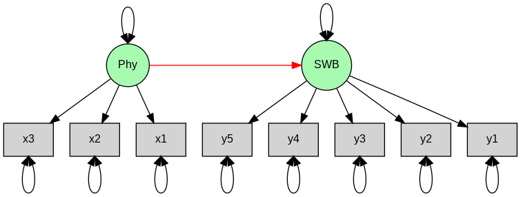

# Key concept 2: Models of the relationship among the constructs

- Most statistical techniques, e.g., regression, are limited to one dependent variable (DV).
- SEM allows researchers to test models with complex relationships.
  - Models are usually represented by path diagrams.
- Model fitting:
  - **Overall** model fit: Does the proposed model fit the data?
  - **Individual** fit: Is the parameter estimate statistically significant?

# Key concept 3: Notations for path diagrams

- Rectangles or squares: observed (or measured) variables
- Circles or ellipses: unobserved (or latent) variables
- Triangles: means or intercepts (may not be used if we are not interested in the mean structure)
- Direct arrows: predictions or “causes”

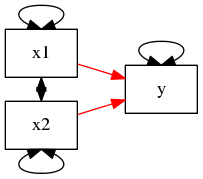

- Double arrows between two variables: covariances

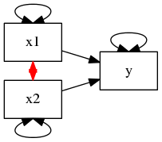

- Double arrows on the same variables: variances

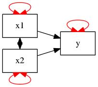

# Confirmatory factor analysis (CFA)

- Linear relationships among latent and observed variables.
- No direct effect on the latent variables.
- It is used to test the construct validity of psychological constructs.

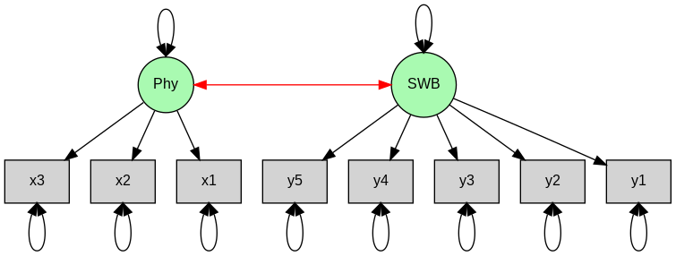

# SEM

- It combines both CFA and path analysis.
- There are observed and latent variables.
- It may include direct effects among the latent variables.

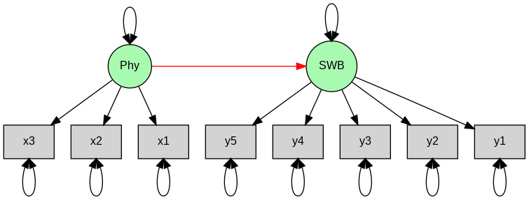

# How to specify a structural equation model?

# Model specification

- We need to instruct the computer programs on what models we would like to fit.
- Approaches to specify SEM
  - *Matrices*: LISREL and OpenMx (open-source software)
  - *Equations*: Mplus, EQS, and lavaan (open-source software)
  - *Path diagrams*: Amos

# Model-identification (1)

- After specifying a model, we need to evaluate whether the proposed model is *testable*.
- Model identification concerns whether there is a unique solution for the model being tested.
- If the model is not *identified*, there is no solution for the proposed model. That is, we are asking a question that has no answer.
- Degrees of freedom (*df*s) of a model:
  - No. of pieces of information available on the covariance matrix: $p^*=p(p+1)/2$ where $p$ is the no. of variables.
  - No. of free parameters in the model: $q$.
  - $df = p^*-q$.

# Model-identification (2)

- A necessary but not sufficient condition for identifying any SEM model is *df* ≥ 0.
- Underidentification:
  - *df* < 0
  - no solution
  - e.g., 3=x+y
- Just identification:
  - *df* =0
  - perfect fit
  - e.g., 3=x+y and 1=x-y then x=2 and y=1
- Overidentification:
  - *df* > 0
  - no perfect solution
  - e.g., 3=x+y, 2=x-y and 5=2x+y

# Model-identification (3)

- The means of the variables are usually excluded from the analysis.
- What is the *df*s of the following model?

[figure not shown]

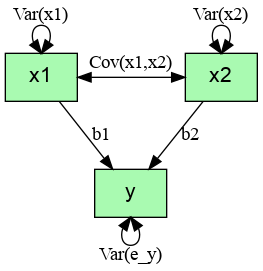

# Model-identification (4)

- All regression models are just identified models (*df*=0).
- We cannot empirically test whether or not the proposed regression models are correct. (They are always correct by *definition*.)
- Over-identified models (*df*s > 0) are usually preferred in CFA/SEM.
- Using a falsification approach, we compare the proposed model (theory) against the data.

# Data in the analysis

Sample data

| x1 | 7 | 11 | 10 | 14 | 11 | 12 | 7 | 14 | 6 | 8 |
| --- | --- | --- | --- | --- | --- | --- | --- | --- | --- | --- |
| y | 5 | 5 | 4 | 7 | 5 | 5 | 4 | 7 | 2 | 12 |

# Model specification

- We can specify a simple regression via a path diagram. We skip the means for the time being.
- The model in the equation: $y = b_0 + b_1 x_1 + e_y$
- Given this model, we can calculate the model implied covariance matrix:
  - $\Sigma(\theta) = \left[ {\begin{array}{cc} b^2_1 Var(x_1) + Var(e_y) & \\ b_1 Var(x_1) & Var(x_1) \\ \end{array} } \right]$
- The above equation (in plain language) means that the population covariance matrix $\Sigma$ is a function of $\theta$.

# Parameter estimation

- How to obtain the parameter estimates in SEM?
  - Theory or model: $\Sigma = \Sigma(\theta)$
  - $\Sigma(\theta)$ is the model implied covariance matrix of the data. It is a function of the parameters ($\theta$) where $\theta$ consists of all the known and unknown parameters.
- In our simple regression example, $\theta=\begin{bmatrix}b_1 \\ var(e_y) \\ var(x_1) \\ \end{bmatrix}=[b_1, var(e_y), var(x_1)]^\mathrm{T}$.
- Data: *S* (sample covariance matrix)
  - If the proposed model is correct, we expect $S \approx \hat{\Sigma}(\hat{\theta})$ where $\hat{\Sigma}$ is called the model implied, reproduced, or fitted covariance matrix.
- We want to find some estimates $\hat{\theta}$ such that *S* and $\hat{\Sigma}$ are **as close as possible**.
- Several estimation methods can be used to define how close these two matrices are. Maximum likelihood (ML) estimation is the most common method in SEM.

# Path model

- What research questions can be answered by path analysis?
- Hypotheses involving only observed (or composite) variables.
  - Observed variables: age, gender, income, educational level, etc.
  - Composite variables: mean scores of several items measuring the same construct.
- Note. We assume that measurement error does not seriously impact our results in path analysis.

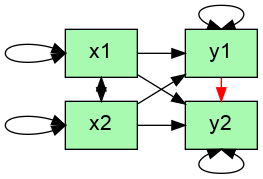

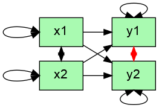

# CFA

# Basic steps in fitting a CFA

- Model specification: What is the proposed model?
- Model- dentification: Will there be a solution for the model?
- Parameter estimation: What are the results of the model?
- The goodness of fit assessment: Does the model fit the data?
- Model modification and comparison: Which model is better? What will we do if the initial model does not fit the data?
- Model interpretations: What are the interpretations of the findings?

# Model specification

- As least two indicators per latent variable are required.
- It is advisable to have at least three indicators per latent variable.
- When there is no constraint:
  - $p^*=(4*5)/2=10$,
  - $q=11$ (3 factor variances/covariance, 4 factor loadings, 4 error variance),
  - $df=p^*-q=-1$!
  - The model is not identified!

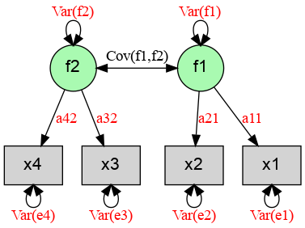

# Model-identification

- Approach 1:
  - Fix the factor variances at some specific positive values, usually 1.0.
  - This only applies to independent (exogenous) latent variables.
  - The *df* of the model: 1
- Approach 2:
  - Fix a factor loading from the latent variable to one observed variable at a non-zero value, usually 1.0.
  - This applies to both independent and dependent (endogenous) latent variables.
  - We have to fix one factor (loading) per latent factor
  - The *df* of the model: 1

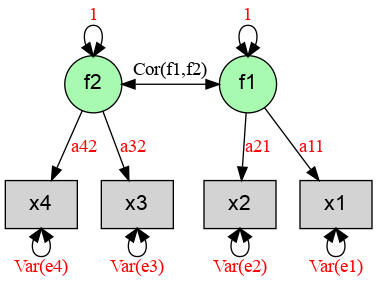

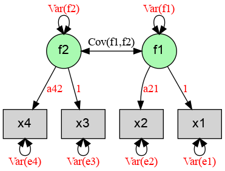

# Model evaluation in SEM

- There are two major tasks in model evaluation.
- Overall model fit: testing whether the proposed model *as a whole* fits the data.
- Individual parameter estimates: testing whether the parameter estimates are significant.
- *Note*. If the overall model does not fit the data, we do not test and interpret the parameter estimates.

[figure not shown]

# Chi-square test statistics (1)

- One major difference between SEM and other statistical techniques is how research hypotheses are tested (Steiger, & Fouladi, 1997):[^1]
  - *Reject-support*: Rejecting the null hypothesis supports the researcher’s belief (e.g., t-test, ANOVA, regression analysis, and MANOVA).
  - *Accept-support*: Accepting the null hypothesis supports the researcher’s belief (e.g., SEM).
  - Based on this rationale, SEM users usually do not want to reject the null hypothesis (the proposed model).

# Chi-square test statistics (2)

- Chi-square test (also known as the likelihood ratio (LR) test):
  - *If the proposed model is correct*, the test statistic has a chi-square distribution with (p*-q) df.
  - This is a “badness-of-fit” index: A large chi-square statistic indicates a poor fit.
  - The proposed model is rejected at .05 if the test statistic is larger than the critical value.

# Issues of chi-square test statistics (1)

- There are several issues associated with the chi-square test:
- Model misspecification:
  - Are there any “true” models in the world?
  - Most SEM users consider models as approximations of reality.
  - [George Box’s](http://en.wikipedia.org/wiki/George_E._P._Box) favorite quote: “Essentially, all models are wrong, but some are useful.”

# Issues of chi-square test statistics (2)

- Violation of underlying assumptions:
  - Data (or residues) are normally distributed.
  - Large samples are required.
  - When data are not normally distributed, especially in clinical studies or in small sample sizes (e.g., N=100 or 200), the test statistic may not follow a chi-square distribution.
- Sensitive to sample size:
  - All proposed models will be rejected when the sample sizes are large enough.
  - Large samples work against researchers!

# Goodness-of-fit indices

- Many SEM users are aware of the problems associated with the chi-square test.
- There are many goodness-of-fit indices developed as alternative measures.
- There are more than 20 goodness-of-fit indices in the market!
- When asked why GFI (one of the fit indices) had been added to LISREL, Karl Joreskog, the developer of LISREL, answered

> “Well, users threaten us saying they would stop using LISREL if it always produces such large chi-squares. So we had to invent something to make people happy. GFI serves that purpose.”

# Incremental fit indices (1)

- They measure the *relative improvement* in fit by comparing the *target* model against the *baseline* model.
- The target model is usually the proposed model.
- The baseline model is usually the model stating that all variables are uncorrelated. It is known as the *independence* model. It can be considered the *worst* model.

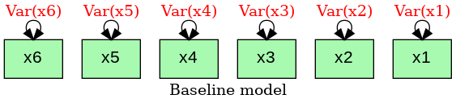

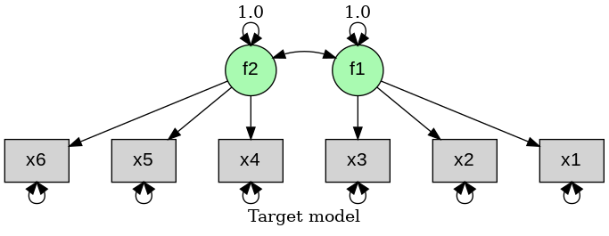

# Incremental fit indices (2)

- Normed fit index (NFI):
  - $\frac{\chi^2_B - \chi^2_T}{\chi^2_B}$
  - $\chi^2_T$ and $\chi^2_B$ are the chi-square statistics of the target and the baseline (or null) models.
  - It measures the proportionate reduction in the chi-square values from the baseline model to the hypothesized model.
- Non-normed fit index (NNFI), which is known as Tucker-Lewis index (TLI):
  - $\frac{\chi^2_B/df_B - \chi^2_T/df_T}{\chi^2_B/df_B-1}$
  - $df_T$ and $df_B$ are the dfs of the target and the baseline models.
  - It adjusts the complexity of the model.

# Incremental fit indices (3)

- Comparative fit index (CFI): $1-\frac{max[(\chi^2_T-df_T),0]}{max[(\chi^2_T-df_T),(\chi^2_B-df_B),0]}$
  - $0 \leq CFI \leq 1$
- What is a well-fitted model?
  - Conventional rule of thumb (without any empirical support): at least > 0.9
  - Goodness-of-fit indices are usually excellent in path analysis. Why? Don’t be fooled by someone showing you a path model with excellent fit indices!

# Residual-based indices (1)

- The residuals (the difference between the model implied covariance matrix and the sample covariance matrix) should be small when the model fits well.
- Standardized root mean square residual (SRMR)
  - It measures the average value of the standardized residuals.
  - It ranges from zero (perfect fit) to one (very poor fit).
  - Rule of thumb: A well-fitted model < .05.

# Residual-based indices (2)

- Root mean square error of approximation (RMSEA) (Browne & Cudeck, 1993)[^2]
  - Similar to SRMR.
  - Advantage: Confidence intervals on RMSEA are available on most SEM packages.
  - Rules of thumb:
    - Close fit: < 0.05
    - Reasonable fit: 0.05 - 0.08
    - Inadequate fit: > 0.1

# What do we need to report in research articles?

# Model modification and comparison

- Comparing nested models: Two models are nested when Model A becomes Model B by fixing or constraining some parameters.
- There are three types of parameters in SEM:
1. *Fixed parameters*:
   - We assign some values to them, e.g., x1 is assigned 1.0.
   - No standard error is available in testing the coefficient of x1 on y.
2. *Free parameters*:
   - The standard error is available on testing the factor loadings on x2 and x3.
3. *Constrained parameters*:
   - They are constrained to be the same. For example, The factor loadings of x2 and x3 are the same.

# An example

- Are the factor loadings the same for items in each factor?
- Psychometric meanings: the items carry the same degree of true score.

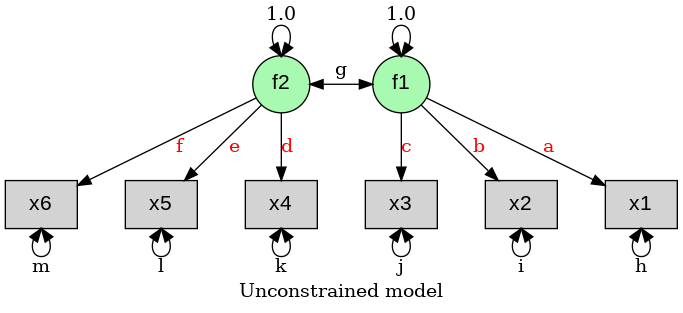

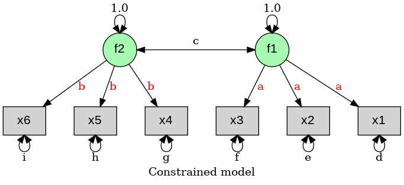

# Is the constrained model as good as the unconstrained model?

- Since there are constraints in the constrained model, it cannot be better than the unconstrained model.
- The question is whether the constrained model is *as good as* the unconstrained model.
- If the constrained model is as good as the unconstrained model (non-significant), we prefer the constrained model.
  - Constrained model: $\chi^2(12)=13.06, p=.36$.
  - Unconstrained model: $\chi^2(8)=2.45, p=.96$.
  - Difference between these models: $\Delta \chi^2(4)=10.61, p=.03$.
- The results showed that the constrained model did not fit the data as well as the unconstrained model.
- Thus, we rejected the null hypothesis that the factor loadings for the latent variables are the same.

# Comparing non-nested models

- Sometimes, the models being compared are non-nested. We cannot convert one model into the other by imposing constraints.
- Chi-square difference test is inappropriate.
- Two popular statistics are Akaike’s information criterion (AIC) and the Bayesian information criterion (BIC):
  - $AIC = \chi^2 -2*df$
  - $BIC = \chi^2 -df*log(n)$
- They measure the parsimonious fit that considers both the model fit and the no. of parameters estimated.
- A smaller value indicates the model is better in compromising between the model fit and the model complexity.
- They can be used to compare nested and non-nested models.
- Choose the model with the smallest AIC or BIC.
- Unlike the chi-square difference test, there is no significance test in comparing AIC or BIC.
- Note:

[figure not shown]

  - Different SEM packages may use different formulas to define AIC and BIC.
  - AIC (and BIC) are not comparable across packages.

# SEM

# Structural equation models

- There are two essential components in SEM.
- Measurement (CFA) model:
  - Are the items grouped according to the theory?
  - Assessment of convergent and discriminant validity of measurement.
  - CFA tests construct validity, not reliability.
- Structural model:
  - What are the relationships among the latent variables?
  - Assessment of predictive validity.

# An example in R: Stability of alienation

- Wheaton et al. (1977)[^5] studied the stability of attitudes over time (1967 and 1971). These include alienation and the relation to background variables such as education and occupation.
- Alienation: Anomia subscale (Anomia) and Powerlessness subscale (Power)
- Socioeconomic status (SES): Duncan’s Socioeconomic Index (SEI) and Years of schooling (EDU)
- The proposed SEM is:

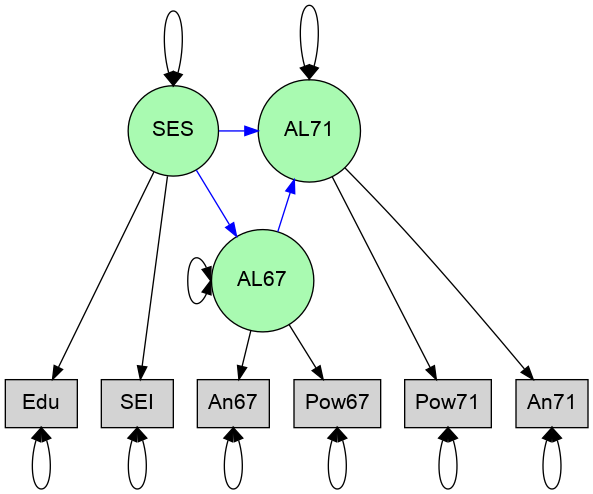

# Model fit

- One nice thing about SEM is that we only need the summary statistics, e.g., a covariance matrix, to fit models.
- The proposed model fits the data marginally well with $\chi^2(df=6)=71.55, p < .001, CFI=0.969, TLI=0.923, RMSEA=0.108, 90\% CI=(0.087, 0.131)$, and $SRMR=0.021$.

```r
## Library to fit SEM
library(lavaan)

## Sample covariance matrix in the lower triangle
lower <- '
11.834
6.947, 9.364
6.819, 5.091, 12.532
4.783, 5.028, 7.495, 9.986
-3.839, -3.889, -3.841, -3.625, 9.610
-2.190, -1.883, -2.175, -1.878, 3.552, 4.503'

## Convert a lower triangle data into a covariance matrix
df <- getCov(lower, diag=TRUE, names=c("anomia67", "power67", "anomia71", "power71", "educ", "SEI"))
df
```

```
##          anomia67 power67 anomia71 power71   educ    SEI
## anomia67   11.834   6.947    6.819   4.783 -3.839 -2.190
## power67     6.947   9.364    5.091   5.028 -3.889 -1.883
## anomia71    6.819   5.091   12.532   7.495 -3.841 -2.175
## power71     4.783   5.028    7.495   9.986 -3.625 -1.878
## educ       -3.839  -3.889   -3.841  -3.625  9.610  3.552
## SEI        -2.190  -1.883   -2.175  -1.878  3.552  4.503
```

```r
my.model1 <- 'AL67 =~ anomia67 + power67    # AL67 is measured by anomia67 and power67; latent variable =~ observed variables
              AL71 =~ anomia71 + power71    # AL71 is measured by anomia71 and power71
              SES =~ educ + SEI             # SES is measured by educ and SEI
              AL71 ~ SES + AL67             # AL71 is modeled by SES and AL67
              AL67 ~ SES                    # AL67 is modeled by SES
'

## Use a covariance matrix and the sample size as the inputs
my.fit1 <- sem(my.model1, sample.cov=df, sample.nobs=932)

## Get the fit measures and standardized solution
summary(my.fit1, fit.measures=TRUE, standardized=TRUE)
```

```
## lavaan 0.6.13 ended normally after 59 iterations
##
##   Estimator                                         ML
##   Optimization method                           NLMINB
##   Number of model parameters                        15
##
##   Number of observations                           932
##
## Model Test User Model:
##
##   Test statistic                                71.550
##   Degrees of freedom                                 6
##   P-value (Chi-square)                           0.000
##
## Model Test Baseline Model:
##
##   Test statistic                              2133.685
##   Degrees of freedom                                15
##   P-value                                        0.000
##
## User Model versus Baseline Model:
##
##   Comparative Fit Index (CFI)                    0.969
##   Tucker-Lewis Index (TLI)                       0.923
##
## Loglikelihood and Information Criteria:
##
##   Loglikelihood user model (H0)             -13100.703
##   Loglikelihood unrestricted model (H1)     -13064.928
##
##   Akaike (AIC)                               26231.407
##   Bayesian (BIC)                             26303.967
##   Sample-size adjusted Bayesian (SABIC)      26256.328
##
## Root Mean Square Error of Approximation:
##
##   RMSEA                                          0.108
##   90 Percent confidence interval - lower         0.087
##   90 Percent confidence interval - upper         0.131
##   P-value H_0: RMSEA <= 0.050                    0.000
```

[output cut: 28 more lines]

```
##     AL67              0.705    0.054   13.169    0.000    0.663    0.663
##   AL67 ~
##     SES              -0.614    0.056  -10.879    0.000   -0.567   -0.567
##
## Variances:
##                    Estimate  Std.Err  z-value  P(>|z|)   Std.lv  Std.all
##    .anomia67          4.011    0.343   11.708    0.000    4.011    0.339
##    .power67           3.188    0.271   11.763    0.000    3.188    0.341
##    .anomia71          3.697    0.373    9.917    0.000    3.697    0.295
##    .power71           3.621    0.292   12.417    0.000    3.621    0.363
##    .educ              2.942    0.499    5.896    0.000    2.942    0.306
##    .SEI               2.607    0.182   14.315    0.000    2.607    0.580
##    .AL67              5.301    0.472   11.235    0.000    0.679    0.679
##    .AL71              3.737    0.387    9.658    0.000    0.424    0.424
##     SES               6.658    0.640   10.403    0.000    1.000    1.000
```

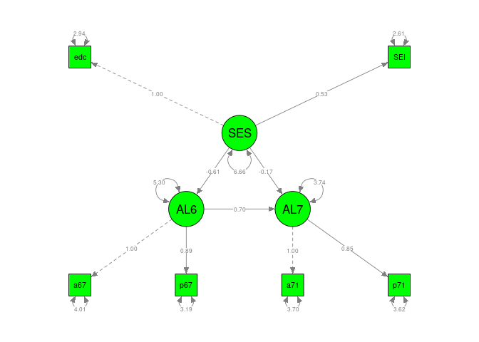

```r
## Library to plot SEM
library(semPlot)

# ## Plot the unstandardized solution
semPaths(my.fit1, whatLabels="est", color="green")
```

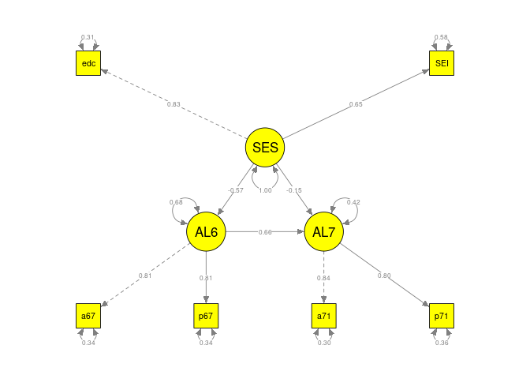

```r
## Plot the standardized solution
semPaths(my.fit1, whatLabels="stand", color="yellow")
```

# Model modification

- Since *Anomia* subscale and the *Powerlessness* subscale were measured twice (1967 and 1971), it is reasonable to expect that the measurement errors may be correlated.
- We may improve the model fit by allowing the residuals to be correlated.

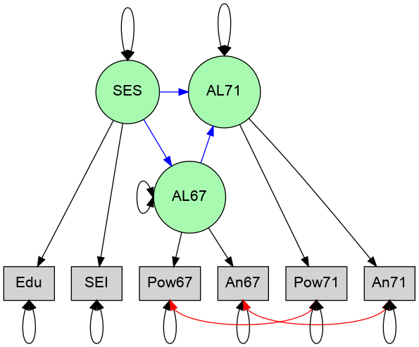

- Results: $\chi^2(4, N=932) = 4.739, p=.315, CFI=1.00, TLI=1.00, RMSEA=0.014$, and $SRMR=.007$. The proposed model fits the data excellently.
- As these two models are nested, we may compare them with a chi-square difference test, which is $\Delta \chi^2(2) = 66.81, p < .001$. Therefore, the model with correlated errors fits much better than the one without it.

```r
my.model2 <- 'AL67 =~ anomia67 + power67    # AL67 is measured by anomia67 and power67
              AL71 =~ anomia71 + power71    # AL71 is measured by anomia71 and power71
              SES =~ educ + SEI             # SES is measured by educ and SEI
              AL71 ~ SES + AL67             # AL71 is modeled by SES and AL67
              AL67 ~ SES                    # AL67 is modeled by SES
              anomia67 ~~ anomia71          # Correlated residuals between anomia67 and anomia71
              power67 ~~ power71            # Correlated residuals between power67 and power71
'

my.fit2 <- sem(my.model2, sample.cov=df, sample.nobs=932)

## Get the fit measures and standardized solutions
summary(my.fit2, fit.measures=TRUE, standardized=TRUE)
```

```
## lavaan 0.6.13 ended normally after 71 iterations
##
##   Estimator                                         ML
##   Optimization method                           NLMINB
##   Number of model parameters                        17
##
##   Number of observations                           932
##
## Model Test User Model:
##
##   Test statistic                                 4.739
##   Degrees of freedom                                 4
##   P-value (Chi-square)                           0.315
##
## Model Test Baseline Model:
##
##   Test statistic                              2133.685
##   Degrees of freedom                                15
##   P-value                                        0.000
##
## User Model versus Baseline Model:
##
##   Comparative Fit Index (CFI)                    1.000
##   Tucker-Lewis Index (TLI)                       0.999
##
## Loglikelihood and Information Criteria:
##
##   Loglikelihood user model (H0)             -13067.298
##   Loglikelihood unrestricted model (H1)     -13064.928
##
##   Akaike (AIC)                               26168.596
##   Bayesian (BIC)                             26250.830
##   Sample-size adjusted Bayesian (SABIC)      26196.840
##
## Root Mean Square Error of Approximation:
##
##   RMSEA                                          0.014
##   90 Percent confidence interval - lower         0.000
##   90 Percent confidence interval - upper         0.053
##   P-value H_0: RMSEA <= 0.050                    0.929
```

[output cut: 35 more lines]

```
##    .anomia71          1.623    0.314    5.176    0.000    1.623    0.356
##  .power67 ~~
##    .power71           0.339    0.261    1.298    0.194    0.339    0.121
##
## Variances:
##                    Estimate  Std.Err  z-value  P(>|z|)   Std.lv  Std.all
##    .anomia67          4.731    0.453   10.441    0.000    4.731    0.400
##    .power67           2.563    0.403    6.360    0.000    2.563    0.274
##    .anomia71          4.399    0.515    8.542    0.000    4.399    0.351
##    .power71           3.070    0.434    7.070    0.000    3.070    0.308
##    .educ              2.802    0.507    5.527    0.000    2.802    0.292
##    .SEI               2.646    0.181   14.598    0.000    2.646    0.588
##    .AL67              4.841    0.467   10.359    0.000    0.683    0.683
##    .AL71              4.083    0.404   10.104    0.000    0.503    0.503
##     SES               6.797    0.649   10.475    0.000    1.000    1.000
```

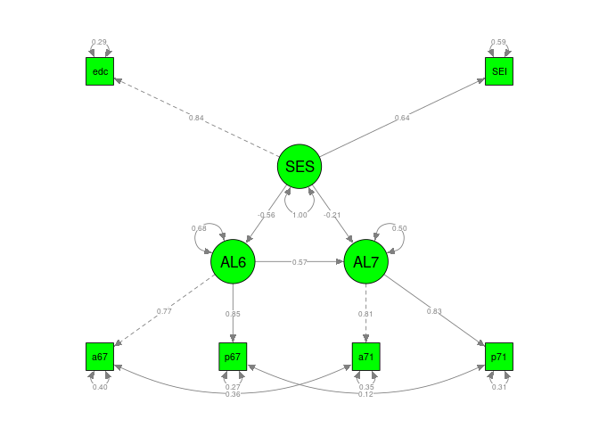

```r
## Plot the standardized solution
semPaths(my.fit2, whatLabels="stand", color="green")
```

```r
## Compare these two nested models
anova(my.fit1, my.fit2)
```

```
##
## Chi-Squared Difference Test
##
##         Df   AIC   BIC   Chisq Chisq diff   RMSEA Df diff Pr(>Chisq)
## my.fit2  4 26169 26251  4.7393
## my.fit1  6 26231 26304 71.5503     66.811 0.18647       2  3.106e-15 ***
## ---
## Signif. codes:  0 '***' 0.001 '**' 0.01 '*' 0.05 '.' 0.1 ' ' 1
```

# Summary

- SEM is a powerful modeling approach to test social and behavioral sciences theories.
- Before interpreting the results, we need to check the goodness-of-fit of the proposed models.
[^1]: Steiger, J. H., & Fouladi, R. T. (1997). [Noncentrality interval estimation and the evaluation of statistical models](http://www.statpower.net/Steiger%20Biblio/Steiger&Fouladi97.PDF). In L. L. Harlow, S. A. Mulaik, & J. H. Steiger (Eds.), *What if there were no significance tests?* (pp. 221-257). Mahwah, NJ: Erlbaum.
[^2]: Browne, M. W., & Cudeck, R. (1993). Alternative ways of assessing model fit. In K. A. Bollen & J. S. Long (Eds.), *Testing Structural Equation Models* (pp. 136-162). Newbury Park, CA: Sage.
[^3]: Hu, L., & Bentler, P. M. (1999). Cutoff criteria for fit indices in covariance structure analysis: Conventional criteria versus new alternatives. *Structural Equation Modeling*, *6*, 1-55.
[^4]: Marsh, H. W., & Hau, K. T., & Wen, Z. (2004). In search of golden rules: Comment on hypothesis-testing approaches to setting cutoff values for fit indices and dangers in overgeneralizing Hu and Bentler’s (1999) findings. *Structural Equation Modeling*, *11*, 320-342.
[^5]: Wheaton, B., Muthen, B., Alwin, D., & Summers, G. (1977). Assessing reliability and stability in panel models. In D. R. Heise (Ed.): *Sociological Methodology* (pp. 84-136). San Francisco: Jossey-Bass.